# Introduction to Python

## 1. Installation

```
- Search for "Python" on Google
- Official website for download, documentation, and tutorials
- Download Python
- Choose the latest stable release

During installation:
- Make sure "Add Python to PATH" is checked
```

## 2. CMD and IDLE

```
Command Prompt (CMD):
- Run Python by typing:
  - python
  - or: py
- Check Python versions:
  - py -0
  - py -3.14
- Exit Python:
  - quit()

Note:
- Working directly in CMD is not very convenient for learning.

IDLE:
- Installing Python also installs IDLE
- IDLE Shell:
  - Good for quick testing
  - Trying ideas
  - Checking variables
- You can configure IDLE from:
  - Options > Configure IDLE

IDLE has two environments:
1. Shell
   - Interactive
   - Used for experiments and small tests
2. Script Editor
   - Open: File > New File
   - No >>> prompt
   - Write longer scripts
   - Run the file to see output in the Shell
   - Scripts can be saved
```

## 3. Variables and Types

```
3. Variables and Types

Variables:
- A variable is a name that stores a value
- Python uses dynamic typing
  - The type is determined at runtime
- You do not need to declare a type in advance

Assigning values:
- This is how we assign a value to a variable:
  - =
- Python evaluates the right-hand side
- Then assigns the result to the left-hand side

Basic variable types:
- Integer (int)
- Decimal (float)
- String (str)
- Binary (bool)
```

```python
a = 5
a
```

```
5
```

```python
a = 5+10*3
a
```

```
35
```

```python
a = a + 7
a
```

```
42
```

```python
type(a)
```

```
int
```

## 4. Numbers

```
Floats vs integers:
- Numbers with a decimal point are floats
- Numbers without a decimal point are integers
- Python decides the type automatically

Type checking:
- Use type() to check the type of a variable

Type conversion:
- int() converts a number to an integer
  - It cuts (does not round) the decimal part
- float() converts a number to a float

Rounding numbers:
- round() rounds a number to the nearest integer
- Python uses a specific rounding rule for .5 values
```

```python
b = 4.5
type(b)
```

```
float
```

```python
c = 4.0
type(c)
```

```
float
```

```python
# transform variables
int(4.8)
```

```
4
```

```python
int(4.999)
```

```
4
```

```python
float(5)
```

```
5.0
```

```python
type(float(5))
```

```
float
```

```python
# some other functions on numbers
round(5.55)
```

```
6
```

```python
round(5.4)
```

```
5
```

```python
round(5.5)
```

```
6
```

```python
round(4.5)
```

```
4
```

```python
ceil(5.1)
```

```
---------------------------------------------------------------------------
NameError                                 Traceback (most recent call last)
Cell In[9], line 1
----> 1 ceil(5.1)

NameError: name 'ceil' is not defined
```

**What happened?**  
Python raised a `NameError: name 'ceil' is not defined`.

**Why?**  
`ceil` is **not a built-in** function in Python.  
So Python does not know what `ceil` refers to yet.

**How do we fix it?**  
We need to import the module that contains `ceil`.  
`ceil` is inside the **math** module, which is part of the **Python Standard Library** (so we do **not** install anything).

```python
import math
```

Now `ceil` is available inside the `math` module.  
So we call it using:

`math.ceil(...)`

```python
math.ceil(5.1)
```

```
6
```

**More about the `math` module**

- The `math` module contains many useful **mathematical functions**
- These functions work on **single numbers** (scalars)
- You can find all available functions in the **official Python documentation**

Important note:

- The `math` module is **not for vectors or arrays**
- For vectorized operations, we use **other modules** (later)

## 5. Strings

**What is a string?**

- A string is **text data**
- Strings are used to represent words, sentences, or characters
- In Python, strings are written inside quotes

Examples of strings:

- "hello"
- 'Python'
- "123" (this is text, not a number)

Important idea:

- `"5"` is a **string**
- `5` is a **number**
- They are **not the same**

```python
s = "Hello"
type(s)
```

```
str
```

```python
s = 'Hello'
type(s)
```

```
str
```

```python
type("20")
```

```
str
```

```python
int("10")
```

```
10
```

```python
int("10.5")
```

```
---------------------------------------------------------------------------
ValueError                                Traceback (most recent call last)
Cell In[17], line 1
----> 1 int("10.5")

ValueError: invalid literal for int() with base 10: '10.5'
```

```python
float("10.5")
```

```
10.5
```

```python
int(float("10.5"))
```

```
10
```

**Indexing and slicing strings**

- Strings are **ordered**
- Each character has a position (index)
- Indexing starts from **0**

Indexing:

- Use square brackets `[]`
- Access a single character by its index

Slicing:

- Used to extract part of a string
- General format:

`[start : stop : step (optional)]`

Important rules:

- `start` is **included**
- `stop` is **excluded** (it is **up to but not including** that position)
- `step` is optional (defalut for step is 1)

```python
s = "Hello"
s[0]
```

```
'H'
```

```python
s[2]
```

```
'l'
```

```python
s[-1]
```

```
'o'
```

```python
s[-2]
```

```
'l'
```

```python
s[0:3] #defalut for step is 1
```

```
'Hel'
```

the stop index is up to but not including

```python
s[0:2+1]
```

```
'Hel'
```

```python
s[::2]
```

```
'Hlo'
```

```python
s[-1:0:-1]
```

```
'olle'
```

```python
s[::-1]
```

```
'olleH'
```

**String methods**

- Strings have many **built-in methods**
- Methods are functions that belong to an object

The dot (`.`) in Python:

- The dot means **“go inside”**
- When you put `.` after something, you access what is **inside that object**

Think of it like this:

- You choose a set (object)
- You put `.` after it
- Now you can see and use the options inside it

Examples:

- `math` is a module
  - `math.` shows available math functions
- A string is also an object
  - `"hello".` shows available string methods

Important idea:

- This is the **same concept** everywhere in Python
- Module → dot → functions
- Object → dot → methods

```python
s.islower()
```

```
False
```

```python
"a".islower()
```

```
True
```

```python
"A".islower()
```

```
False
```

```python
"AbcdE".islower()
```

```
False
```

```python
"AbcdE".isupper()
```

```
False
```

```python
"AE".isupper()
```

```
True
```

**Meaning of the dot (`.`) in Python**

Dot with modules:

- Using `.` after a module means:
  - Go **inside the module**
  - Access any **options (functions, variables)** available in that module

Example:

- `math.` → work with what is inside the `math` module

Dot with objects (variables):

- Using `.` after an object means:
  - Look at what **options the class of that object provides**
  - These options are called **methods**

Important idea:

- Every object in Python comes from a **class**
- The dot shows what that class allows you to work with

Summary:

- `module . option` → options inside a module
- `object . method` → methods defined by the object’s class

## 7. Binary

```python
a = True
type(a)
```

```
bool
```

```python
b = False
type(b)
```

```
bool
```

### Math operators

```python
5*5
```

```
25
```

```python
5+10
```

```
15
```

```python
10*3.1 # final result is float automatically
```

```
31.0
```

```python
10/5
```

```
2.0
```

```python
11/3
```

```
3.6666666666666665
```

```python
11//3
```

```
3
```

```python
11%3
```

```
2
```

```python
5**2
```

```
25
```

```python
2 * "abc"  # this is why automatic transformations of type matter in Python
```

```
'abcabc'
```

```python
"ab" + "cd"
```

```
'abcd'
```

```python
"ab" + "ab"
```

```
'abab'
```

```python
"ab" * 2
```

```
'abab'
```

```python
"a"/5
```

```
---------------------------------------------------------------------------
TypeError                                 Traceback (most recent call last)
Cell In[42], line 1
----> 1 "a"/5

TypeError: unsupported operand type(s) for /: 'str' and 'int'
```

```python
"a"**2
```

```
---------------------------------------------------------------------------
TypeError                                 Traceback (most recent call last)
Cell In[43], line 1
----> 1 "a"**2

TypeError: unsupported operand type(s) for ** or pow(): 'str' and 'int'
```

```python
5.4*"abc"
```

```
---------------------------------------------------------------------------
TypeError                                 Traceback (most recent call last)
Cell In[44], line 1
----> 1 5.4*"abc"

TypeError: can't multiply sequence by non-int of type 'float'
```

```python
5.0*"a"
```

```
---------------------------------------------------------------------------
TypeError                                 Traceback (most recent call last)
Cell In[45], line 1
----> 1 5.0*"a"

TypeError: can't multiply sequence by non-int of type 'float'
```

## 8. Conditions

**Conditional statements in Python**

- Conditions allow us to **control the flow** of a program
- Python uses **indentation** to define blocks

Basic structure:

```
if condition1:
    statement_a   # indentation matters
elif condition2:
    statement_b
elif condition3:
    statement_c
...
else:
    statement_d

To construct condition, we want operators that return to us some boolean variable
```

```python
10 > 5
```

```
True
```

```python
10 < 5
```

```
False
```

```python
10 = 5
```

```
  Cell In[52], line 1
    10 = 5
    ^
SyntaxError: cannot assign to literal here. Maybe you meant '==' instead of '='?
```

```python
10 == 5
```

```
False
```

```python
 "hi" == "bye"
```

```
False
```

```python
"hi" == "hi"
```

```
True
```

```python
10 != 4
```

```
True
```

```python
if 10 > 5:
    print("hi")
```

```
hi
```

```python
a = 5
a
```

```
5
```

```python
print("Hi:", a)
```

```
Hi: 5
```

```python
a = 5
print("Hi:", a)
if a > 5:
    print("is above 5")
elif a < 5:
    print("is below 5")
else:
    print("equals 5")
```

```
Hi: 5
equals 5
```

```python
a = 5
print("Hi:", a)
if a > 5:
    print("is above 5")
```

```
Hi: 5
```

```python
a = 6
print("Hi:", a)
if a > 5:
    print("is above 5")
    print("Bye")
```

```
Hi: 6
is above 5
Bye
```

```python
a = 6
print("Hi:", a)
if a > 5:
    print("is above 5")
print("Bye")
```

```
Hi: 6
is above 5
Bye
```

```python
a = 5
print("Hi:", a)
if a > 5:
    print("is above 5")
print("Bye")
```

```
Hi: 5
Bye
```

```python
a = 5
print("Hi:", a)
if a > 5:
    print("is above 5")
print("Bye")
else:
    print("python")
```

```
  Cell In[65], line 6
    else:
    ^
SyntaxError: invalid syntax
```

**Why does this code not work?**

Python raises a **SyntaxError**.

**Reason:**

- In Python, `else` must come **immediately after** its corresponding `if` or `elif`
- You cannot put any other statement between `if` and `else`

What went wrong here:

- The line `print("Bye")` breaks the `if`–`else` structure
- When Python sees `else`, it o longer knows which `if` it belongs to

Important rule:

- `else` must be aligned with its `if`
- No code is allowed between them

Indentation alone is not enough — **structure matters**

### Indentation in Python

- Whenever you see `:` in Python, be careful about **indentation**
- Indentation must be **consistent**
  - It does not matter how many spaces you use
  - But you must use the **same indentation style** everywhere
  - Do not mix spaces and tabs

Important idea:

- Python works with **indentation**
- It does not use `{}` or keywords like `end`
- This makes Python **visually cleaner and more readable**

```python
a = 6
print("Hi:", a)
if a > 5:
    print("is above 5")
elif a > 10:
    print("is below 5")
else:
    print("equals 5")
```

```
Hi: 6
is above 5
```

## 8. Loops

**What is a loop?**

- A loop is used to **repeat a block of code**
- Python has two main types of loops:
  - `for` loop
  - `while` loop

```
for i in iterable:
    statement

while condition:
    statement
```

**What is an iterable?**

An iterable is whatever set that we can take out its  
different elements using indexing `[]`.

Examples of iterables:

- strings
- lists
- ranges

We can loop over an iterable and access its elements one by one.

```python
for i in "Hello":
    print(i)
```

```
H
e
l
l
o
```

```python
# sometimes you do this
for i in "Hello":
    print(5)
```

```
5
5
5
5
5
```

```python
for i in 100:
    print(5)
```

```
---------------------------------------------------------------------------
TypeError                                 Traceback (most recent call last)
Cell In[71], line 1
----> 1 for i in 100:
      2     print(5)

TypeError: 'int' object is not iterable
```

```python
for i in "100":
    print(5)
```

```
5
5
5
```

```python
for i in "100":
    print(int(i))
```

```
1
0
0
```

```python
for i in True:
    print(int(i))
```

```
---------------------------------------------------------------------------
TypeError                                 Traceback (most recent call last)
Cell In[74], line 1
----> 1 for i in True:
      2     print(int(i))

TypeError: 'bool' object is not iterable
```

```python
 for i in range(0,5):
    print(i)
```

```
0
1
2
3
4
```

```python
 for i in range(5):
    print(i)
```

```
0
1
2
3
4
```

```python
 for i in range(5+1):
    print(i)
```

```
0
1
2
3
4
5
```

```python
 for i in range(1,5+1):
    print(i)
```

```
1
2
3
4
5
```

```python
 for i in range(1,5+1,2):
    print(i)
```

```
1
3
5
```

```python
for i in range(1,5+1,2):
    print(i)
    print("hi")
```

```
1
hi
3
hi
5
hi
```

**Looping over data structures**

- Looping over data structures (like lists, dictionaries, etc.) will be covered later

**When to use `for` vs `while`**

- `for` is used when:
  - We want to write a loop over a **set**
  - Or when we **know how many times** we want to repeat a certain task
- `while` is used when:
  - We do **not know exactly how many times** the work will be repeated
  - But we **do know the condition** under which it should end

```
while condition:
    statement
```

```python
a = 5
while a > 5:
    print("Hi")
```

```
never do this:
a = 5
while a > 4:
    print("Hi")
```

**Why should you never do this?**

- The condition `a > 4` is **always True**
- The value of `a` never changes
- So the loop **never ends**

What would happen if this code ran:

- `"Hi"` would be printed **forever**
- This creates an **infinite loop**

Important rule for `while` loops:

- Something inside the loop must **change the condition**
- Otherwise, the loop will never stop

```python
a = 5
while a >= 0:
    print("Hi")
    a -= 1
```

```
Hi
Hi
Hi
Hi
Hi
Hi
```

```python
# Sometime stop condition is inside the code block
a = 5
while True:
    print("Hi")
    a -= 1
    if a < 0:
        break
```

```
Hi
Hi
Hi
Hi
Hi
Hi
```

**What does this code do?**

- The loop starts with `while True`, which means the loop is **initially infinite**
- `"Hi"` is printed in each iteration
- The value of `a` is decreased by 1 every time the loop runs
- The `if` statement checks whether `a` has become negative

**What is `break`?**

- `break` is a control statement used **inside loops**
- When Python encounters `break`, it **immediately exits the loop**
- Execution continues with the code **after the loop**

**Why is `break` needed here?**

- The loop condition (`True`) never becomes False on its own
- The stopping condition is instead defined **inside the loop**
- When `a < 0` becomes True, `break` stops the loop

**Key idea**

- `break` allows us to **terminate a loop based on a condition**
- This is useful when the stopping logic cannot be written directly in the `while` condition

**Important note about `break`**

- `break` can appear **anywhere inside a loop**
- As soon as Python encounters `break`, it **immediately exits the loop**
- No further statements inside the loop are executed

**`break` in a `for` loop**

- `break` can also be used **inside a `for` loop**
- As soon as `break` is encountered, the loop **stops immediately**
- The loop does **not** continue to the next iteration

Example:

```python
for i in range(10):
    if i == 4:
        break
    print(i)
```

```
0
1
2
3
```

```python
for i in range(10):
    print(i)
    if i == 4:
        break
```

```
0
1
2
3
4
```

```python
for i in range(10):
    if i == 4:
        continue
    print(i)
```

```
0
1
2
3
5
6
7
8
9
```

```python
for i in range(10):
    if i == 4:
        pass
    print(i)
```

```
0
1
2
3
4
5
6
7
8
9
```

## 10. Python Standard Library

- Python has many useful modules already available in the **Python Standard Library (PSL)**
- These modules are **not built-in by default**, so we usually need to `import` them
- The pattern is the same as what we saw with `math`:
  - try a function → error → find the right module → import → use it correctly

Current working directory (OS module)

Sometimes we want to know **where Python is running** (the current working directory). We will try `getcwd()` first.

```python
getcwd()
```

```
---------------------------------------------------------------------------
NameError                                 Traceback (most recent call last)
Cell In[92], line 1
----> 1 getcwd()

NameError: name 'getcwd' is not defined
```

**What happened?**

- Python raises a `NameError`
- Because `getcwd` is **not built-in**
- It belongs to the `os` module (PSL)

```python
import os
```

Now we call the function from inside the module using dot notation:

`module.function()`

```python
os.getcwd()
```

```
'C:\\Users\\eh1156a\\OneDrive - american.edu\\MyFiles\\Uni\\PhD\\Other\\JN codes'
```

### Random numbers (random module)

Now we want a random integer.

We will try `randint(5, 25)` first.

```python
randint(5, 25)
```

```
---------------------------------------------------------------------------
NameError                                 Traceback (most recent call last)
Cell In[93], line 1
----> 1 randint(5, 25)

NameError: name 'randint' is not defined
```

**What happened?**

- Python raises a `NameError: name 'randint' is not defined`
- Because `randint` is not built-in
- It belongs to the `random` module (PSL)

```python
import random
```

Now we can call `randint` using dot notation:

```python
random.randint(5, 25)
```

```
13
```

### Two common ways to use functions from a module

**Option 1 (recommended for beginners):**

- Import the module
- Use dot notation: `random.randint(...)`

**Option 2 (shortcut import):**

- Import the function directly
- Then call it without `random.`

```python
from random import randint
```

```python
randint(5, 25)
```

```
22
```

### PSL vs non-PSL (what if it is not in the Standard Library?)

- If a module is part of the **Python Standard Library**, you only need to `import` it
- If a module is **not** in PSL, you must install it first (usually from **PyPI**)

Typical installation method:

- Use `pip install package_name`

Example idea:

- Packages like `numpy`, `pandas`, `matplotlib` are **not** PSL (they must be installed)

## 11. Data Structures

**What are data structures?**

- Data structures are used to **store and organize multiple values**
- Python provides several built-in data structures
- Each data structure is designed for a **different purpose**

Common built-in data structures:

- `list`
- `dict`
- `set`
- `tuple`

### List

**What is a list?**

- A list is an **ordered** collection of elements
- Lists can store:
  - numbers
  - strings
  - mixed types
- Lists are **mutable**
  - meaning their content can be changed

```python
# list
a = [1, 2, 3]
a, type(a)
```

```
([1, 2, 3], list)
```

```python
a = [1, 2.3, 3]
a, type(a)
```

```
([1, 2.3, 3], list)
```

```python
a = [1, 2.3, 3, "hi", [1, 2.4, [0, "list"], 5.3], "python"]
a
```

```
[1, 2.3, 3, 'hi', [1, 2.4, [0, 'list'], 5.3], 'python']
```

```python
a[0]
```

```
1
```

```python
a[4]
```

```
[1, 2.4, [0, 'list'], 5.3]
```

```python
a[4]
```

```
[1, 2.4, [0, 'list'], 5.3]
```

```python
a[4][2]
```

```
[0, 'list']
```

```python
a[-1]
```

```
'python'
```

```python
a[0::2]
```

```
[1, 3, [1, 2.4, [0, 'list'], 5.3]]
```

```python
a
```

```
[1, 2.3, 3, 'hi', [1, 2.4, [0, 'list'], 5.3], 'python']
```

```python
a[0]
```

```
1
```

```python
a[0] = 1000
a
```

```
[1000, 2.3, 3, 'hi', [1, 2.4, [0, 'list'], 5.3], 'python']
```

```python
a.append(10000)
a
```

```
[1000, 2.3, 3, 'hi', [1, 2.4, [0, 'list'], 5.3], 'python', 10000]
```

```python
a.pop()
a
```

```
[1000, 2.3, 3, 'hi', [1, 2.4, [0, 'list'], 5.3], 'python']
```

```python
a.pop(0) #these are mothod because a (the list) is a class and we call method the functions which are in classes
a
```

```
[2.3, 3, 'hi', [1, 2.4, [0, 'list'], 5.3], 'python']
```

```python
"hi" not in a
```

```
False
```

```python
for i in a:
    print(i)
```

```
2.3
3
hi
[1, 2.4, [0, 'list'], 5.3]
python
```

```python
# list is not good for calculation
[1, 2, 3] + [4, 5, 6]
```

```
[1, 2, 3, 4, 5, 6]
```

```python
[1, 2, 3]*2
```

```
[1, 2, 3, 1, 2, 3]
```

```python
[1, 2, 3]**2
```

```
---------------------------------------------------------------------------
TypeError                                 Traceback (most recent call last)
Cell In[120], line 1
----> 1 [1, 2, 3]**2

TypeError: unsupported operand type(s) for ** or pow(): 'list' and 'int'
```

## 12. Dictionary

**Why lists are not good for tagged data**

- Lists are good for **ordered data**
- But lists are **not suitable for tagged or labeled data**

Example of tagged data:

- city → id, name, population, rainfall, average age

Problem with lists:

- Values are stored only by **position**
- It is hard to remember what each position means
- Data is **not easily trackable or readable**

**What is a dictionary?**

- A dictionary stores data as **key–value pairs**
- Each value is accessed using a **key**, not an index
- Dictionaries are designed for **labeled (tagged) data**
- Dictionary keys must be **unique**
  - A key **cannot be repeated**
- Keys are used to **identify values**

Key types:

- Keys should be of type:
  - `str`
  - `int`

Important notes:

- If a key is repeated, the **last value overwrites the previous one**
- Keys are used to **access values**, not positions

```python
d = {}
type(d)
```

```
dict
```

```python
d = {"key1": "value1", "key2": "value2"}
d
```

```
{'key1': 'value1', 'key2': 'value2'}
```

```python
d = {"k1": 23, "k2": 100}
d
```

```
{'k1': 23, 'k2': 100}
```

```python
d = {0: 20, 1: 215, 3: 54}
d
```

```
{0: 20, 1: 215, 3: 54}
```

```python
d = {0: 20, 1: 215, 3: 54, 3: 143}
d
```

```
{0: 20, 1: 215, 3: 143}
```

```python
d = {1010:{"name": "DC", "pop":700, "rain": [21, 43, 29]},
     1020:{"name": "NYC", "pop":3000, "rain": [30.5, 34/2, 23.4]}}
d
```

```
{1010: {'name': 'DC', 'pop': 700, 'rain': [21, 43, 29]},
 1020: {'name': 'NYC', 'pop': 3000, 'rain': [30.5, 17.0, 23.4]}}
```

```python
d[0]
```

```
---------------------------------------------------------------------------
KeyError                                  Traceback (most recent call last)
Cell In[130], line 1
----> 1 d[0]

KeyError: 0
```

```python
d[1010]
```

```
{'name': 'DC', 'pop': 700, 'rain': [21, 43, 29]}
```

```python
d[1010]["name"]
```

```
'DC'
```

```python
g = {"a": 100, "b": 200, "c": 300}
g
```

```
{'a': 100, 'b': 200, 'c': 300}
```

```python
for i in g:
    print(i)
```

```
a
b
c
```

```python
for i in g:
    print(g[i])
```

```
100
200
300
```

```python
for k, v in g.items():
    print("key is:", k, ", and value is:", v)
```

```
key is: a , and value is: 100
key is: b , and value is: 200
key is: c , and value is: 300
```

## 13. Set

**What is a set?**

- A set is a collection of **unique elements**
- Sets are **unordered**
- Duplicate values are **automatically removed**

Important properties:

- No repeated elements
- Order does not matter
- Elements are accessed by **membership**, not by index

**Why use a set?**

- When you only care about **whether something exists**
- When you want to **remove duplicates**
- When order is not important

**Set as a mathematical concept**

- A set in Python is very similar to a **mathematical set**
- You can perform common **set operations** on sets, such as:
  - union (اجتماع)
  - intersection (اشتراک)
  - difference (تفریق)

Important idea:

- Sets are designed for **set logic**, not indexing or ordering

```python
s = {1, 2, 3, 4}
s
```

```
{1, 2, 3, 4}
```

```python
type(s)
```

```
set
```

```python
s = {2, 2, 2, 5, 6, 6, 8, 8, 8, 9, 12}
s
```

```
{2, 5, 6, 8, 9, 12}
```

```python
s[0]
```

```
---------------------------------------------------------------------------
TypeError                                 Traceback (most recent call last)
Cell In[147], line 1
----> 1 s[0]

TypeError: 'set' object is not subscriptable
```

```python
for i in s:
    print(i)
```

```
2
5
6
8
9
12
```

```python
a = {1, 2, 10, 20}
b = {4, 5, 1, 2}
a.union(b)
```

```
{1, 2, 4, 5, 10, 20}
```

```python
a.intersection(b)
```

```
{1, 2}
```

```python
a.difference(b)
```

```
{10, 20}
```

```python
b.difference(a)
```

```
{4, 5}
```

## 14. Tuple

**What is a tuple?**

- A tuple is an **ordered** collection of elements
- Tuples are **immutable**
  - meaning their content **cannot be changed** after creation

Important properties:

- Order matters
- Elements are accessed using **indexing**
- Values cannot be modified once the tuple is created

**Why use a tuple?**

- When you want to store a group of values that should **not change**
- When data represents a **fixed structure**
- Tuples are often used for:
  - coordinates
  - settings
  - return values from functions

```python
t = (1, 2, 3, 4)
t
```

```
(1, 2, 3, 4)
```

```python
type(t)
```

```
tuple
```

```python
t[0]
```

```
1
```

```python
for i in t:
    print(i)
```

```
1
2
3
4
```

```python
t[0] = 100
```

```
---------------------------------------------------------------------------
TypeError                                 Traceback (most recent call last)
Cell In[159], line 1
----> 1 t[0] = 100

TypeError: 'tuple' object does not support item assignment
```

```python
a = 1, 2, 3
type(a)
```

```
tuple
```

```python
10*2+30
```

```
50
```

```python
10*(2+30)
```

```
320
```

```python
a = (10)
a, type(a)
```

```
(10, int)
```

```python
a = (34,)
a, type(a)
```

```
((34,), tuple)
```

```python
a = 3,
a, type(a)
```

```
((3,), tuple)
```

```python
a, b = 2, 5
print(a)
print(b)
```

```
2
5
```

## 15. Functions

```
def func_name(optional_arguments):
    statement
    ...
    return optional_value
```

**What is a function?**

- A function is a reusable block of code that performs a specific task
- Instead of writing the same logic again and again, we write it once and **call** it when needed

### 1) Function definition (`def`)

- `def` is the keyword used to define a function
- `func_name` is the name of the function (you choose it)
- `optional_arguments` are inputs to the function (also called **parameters**)
- After the line ends with `:`, the function body must be **indented**

### 2) Arguments (inputs)

- Arguments are the values the function receives to work with
- A function can have:
  - no arguments
  - one argument
  - multiple arguments

Example:

- In `power2(a)`, the function takes one input called `a`

### 3) The function body

- The indented lines are the steps the function performs
- The code inside the function runs **only when the function is called**

### 4) `return` (output)

- `return` sends a value back to the place where the function was called
- When Python reaches `return`, the function **stops immediately**
- If a function has no `return`, it returns `None` by default

```python
def power2(a):
    return a**2
```

```python
power2(6)
```

```
36
```

```python
power2(6.6)
```

```
43.559999999999995
```

```python
def f1(): # function without input
    print(10)
```

```python
f1()
```

```
10
```

```python
import os
```

```python
os.getcwd() # getcwd() is a function without input
```

```
'C:\\Users\\eh1156a\\OneDrive - american.edu\\MyFiles\\Uni\\PhD\\Other\\JN codes'
```

```python
def power2(a):
    b = a**2
    #return b
```

```python
power2(5)
```

```python
print(power2(5))
```

```
None
```

```python
c = power2(5)
```

```python
b
```

```
5
```

```python
def power2_3(a):
    return a**2, a**3
```

```python
power2_3(10)
```

```
(100, 1000)
```

```python
def power2_3(a):
    d = {"power2": a**2, "power3": a**3}
    return d
```

```python
power2_3(10)
```

```
{'power2': 100, 'power3': 1000}
```

```python
def even(l):
    a = []
    for i in l:
        if i%2 == 0:
            a.append(i)
    return a
```

```python
even([1, 5, 2, 14, 17, 18])
# less work
```

```
[2, 14, 18]
```

```python
even("hello")
```

```
---------------------------------------------------------------------------
TypeError                                 Traceback (most recent call last)
Cell In[193], line 1
----> 1 even("hello")

Cell In[191], line 4, in even(l)
      2 a = []
      3 for i in l:
----> 4     if i%2 == 0:
      5         a.append(i)
      6 return a

TypeError: not all arguments converted during string formatting
```

```python
isinstance(5, int)
```

```
True
```

```python
isinstance(5, str)
```

```
False
```

```python
type(5) == int
```

```
True
```

```python
type(5) == str
```

```
False
```

```python
def even(l):
    if isinstance(l, list):
        pass
    else:
        raise TypeError("Input must be a list")
    a = []
    for i in l:
        if i % 2 == 0:
            a.append(i)
    return a
```

```python
even("hello")
```

```
---------------------------------------------------------------------------
TypeError                                 Traceback (most recent call last)
Cell In[199], line 1
----> 1 even("hello")

Cell In[198], line 5, in even(l)
      3     pass
      4 else:
----> 5     raise TypeError("Input must be a list")
      6 a = []
      7 for i in l:

TypeError: Input must be a list
```

```python
def even(l):
    if not isinstance(l, list):
        raise TypeError("Input must be a list")
    a = []
    for i in l:
        if i%2 == 0:
            a.append(i)
    return a
```

```python
even("hello")
```

```
---------------------------------------------------------------------------
TypeError                                 Traceback (most recent call last)
Cell In[201], line 1
----> 1 even("hello")

Cell In[200], line 3, in even(l)
      1 def even(l):
      2     if not isinstance(l, list):
----> 3         raise TypeError("Input must be a list")
      4     a = []
      5     for i in l:

TypeError: Input must be a list
```

```python
even([1,2,3,4])
```

```
[2, 4]
```

```python
def f2(l):
    for i in l:
        if i == 5:
            return
    return l
```

```python
print(f2([1,2,5,3,2,6]))
```

```
None
```

```python
print(f2([1,2,3,2,6]))
```

```
[1, 2, 3, 2, 6]
```

## 17. NumPy – Matplotlib – Pandas

These are three of the most important external Python libraries used for **scientific computing and data analysis**.

### NumPy

- Used for **numerical and matrix calculations**
- Provides fast operations on arrays and matrices
- Foundation for many other scientific libraries

### Matplotlib

- Used for **data visualization**
- Allows you to create plots, charts, and figures
- Often used together with NumPy and Pandas

### Pandas

- Used to **read and write data**
- Provides tools for:
  - data cleaning
  - data manipulation
  - data analysis
- Very common in data science and statistics

### Installing external libraries

These libraries are **not part of the Python Standard Library**, so they must be installed.

You can install them using `pip`.

From Jupyter Notebook:

```
pip install numpy
```

```python
import numpy as np
import matplotlib
import pandas as pd
```

```python
a = np.array([1, 2, 3])
b = np.array([10, 20, 30])
type(a)
```

```
numpy.ndarray
```

```python
a + b
```

```
array([11, 22, 33])
```

```python
a**2
```

```
array([1, 4, 9])
```

```python
np.cos([0, 3.1415926535])
```

```
array([ 1., -1.])
```

```python
x = np.linspace(-1, 1, 100)
x
```

```
array([-1.        , -0.97979798, -0.95959596, -0.93939394, -0.91919192,
       -0.8989899 , -0.87878788, -0.85858586, -0.83838384, -0.81818182,
       -0.7979798 , -0.77777778, -0.75757576, -0.73737374, -0.71717172,
       -0.6969697 , -0.67676768, -0.65656566, -0.63636364, -0.61616162,
       -0.5959596 , -0.57575758, -0.55555556, -0.53535354, -0.51515152,
       -0.49494949, -0.47474747, -0.45454545, -0.43434343, -0.41414141,
       -0.39393939, -0.37373737, -0.35353535, -0.33333333, -0.31313131,
       -0.29292929, -0.27272727, -0.25252525, -0.23232323, -0.21212121,
       -0.19191919, -0.17171717, -0.15151515, -0.13131313, -0.11111111,
       -0.09090909, -0.07070707, -0.05050505, -0.03030303, -0.01010101,
        0.01010101,  0.03030303,  0.05050505,  0.07070707,  0.09090909,
        0.11111111,  0.13131313,  0.15151515,  0.17171717,  0.19191919,
        0.21212121,  0.23232323,  0.25252525,  0.27272727,  0.29292929,
        0.31313131,  0.33333333,  0.35353535,  0.37373737,  0.39393939,
        0.41414141,  0.43434343,  0.45454545,  0.47474747,  0.49494949,
        0.51515152,  0.53535354,  0.55555556,  0.57575758,  0.5959596 ,
        0.61616162,  0.63636364,  0.65656566,  0.67676768,  0.6969697 ,
        0.71717172,  0.73737374,  0.75757576,  0.77777778,  0.7979798 ,
        0.81818182,  0.83838384,  0.85858586,  0.87878788,  0.8989899 ,
        0.91919192,  0.93939394,  0.95959596,  0.97979798,  1.        ])
```

```python
y = np.sin(x)
y
```

```
array([-0.84147098, -0.83038482, -0.81895978, -0.8072005 , -0.79511181,
       -0.78269862, -0.76996601, -0.75691917, -0.74356342, -0.72990422,
       -0.71594714, -0.70169788, -0.68716224, -0.67234618, -0.65725572,
       -0.64189703, -0.62627638, -0.61040014, -0.59427479, -0.57790691,
       -0.56130318, -0.54447039, -0.52741539, -0.51014514, -0.49266671,
       -0.47498721, -0.45711386, -0.43905397, -0.42081489, -0.40240408,
       -0.38382904, -0.36509735, -0.34621667, -0.3271947 , -0.30803919,
       -0.28875797, -0.26935891, -0.24984992, -0.23023896, -0.21053404,
       -0.1907432 , -0.17087452, -0.1509361 , -0.13093608, -0.11088263,
       -0.09078392, -0.07064817, -0.05048358, -0.03029839, -0.01010084,
        0.01010084,  0.03029839,  0.05048358,  0.07064817,  0.09078392,
        0.11088263,  0.13093608,  0.1509361 ,  0.17087452,  0.1907432 ,
        0.21053404,  0.23023896,  0.24984992,  0.26935891,  0.28875797,
        0.30803919,  0.3271947 ,  0.34621667,  0.36509735,  0.38382904,
        0.40240408,  0.42081489,  0.43905397,  0.45711386,  0.47498721,
        0.49266671,  0.51014514,  0.52741539,  0.54447039,  0.56130318,
        0.57790691,  0.59427479,  0.61040014,  0.62627638,  0.64189703,
        0.65725572,  0.67234618,  0.68716224,  0.70169788,  0.71594714,
        0.72990422,  0.74356342,  0.75691917,  0.76996601,  0.78269862,
        0.79511181,  0.8072005 ,  0.81895978,  0.83038482,  0.84147098])
```

```python
import matplotlib.pyplot as plt
```

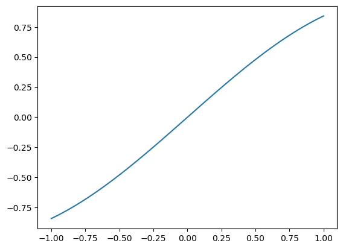

```python
fig, ax = plt.subplots()
ax.plot(x, y)
```

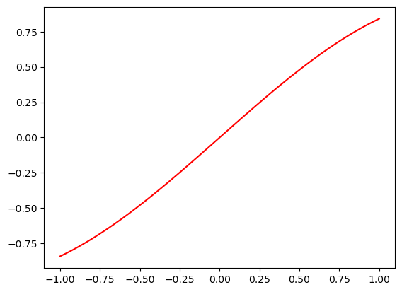

```python
fig, ax = plt.subplots()
ax.plot(x, y, c="red")
```

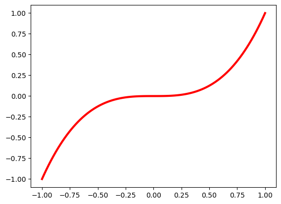

```python
fig, ax = plt.subplots()
ax.plot(x, x**3, c="red", lw=3)
```

```python
import pandas as pd
```

```python
data = pd.read_csv(r"C:\Users\eh1156a\OneDrive - american.edu\Book1.csv")
data
```

|  | col_1 | col_2 | col_3 | col_4 | col_5 |
| --- | --- | --- | --- | --- | --- |
| 0 | 13 | dsw | 2 | 1 | f |
| 1 | 23 | fda | 5 | 0 | . |
| 2 | 32 | dwd | 4 | 0 | NaN |
| 3 | 23 | gea | 1 | 0 | a |
| 4 | 13 | r3a | 6 | 1 | NaN |
| 5 | 15 | qet | 2 | 1 | c |
| 6 | 12 | qrg | 5 | 0 | NaN |
| 7 | 24 | cdu | 35 | 1 | f |
| 8 | 13 | vny | 7 | 0 | g |
| 9 | 52 | qry | 4 | 1 | NaN |

```python
type(data)
```

```
pandas.core.frame.DataFrame
```

```python
data.columns
```

```
Index(['col_1', 'col_2', 'col_3', 'col_4', 'col_5'], dtype='object')
```

```python
c = data[data.columns[0]]
c
```

```
0    13
1    23
2    32
3    23
4    13
5    15
6    12
7    24
8    13
9    52
Name: col_1, dtype: int64
```

```python
c = data.columns[0]
c
```

```
'col_1'
```

```python
type(c)
```

```
str
```

```python
data.iloc[0, 0]
```

```
13
```

```python
data.iloc[1, 2]
```

```
5
```

```python
data.loc[0, data.columns[0]]
```

```
13
```

```python
data["col_new"] = 2*data[data.columns[0]]
```

```python
data
```

|  | col_1 | col_2 | col_3 | col_4 | col_5 | col_new |
| --- | --- | --- | --- | --- | --- | --- |
| 0 | 13 | dsw | 2 | 1 | f | 26 |
| 1 | 23 | fda | 5 | 0 | . | 46 |
| 2 | 32 | dwd | 4 | 0 | NaN | 64 |
| 3 | 23 | gea | 1 | 0 | a | 46 |
| 4 | 13 | r3a | 6 | 1 | NaN | 26 |
| 5 | 15 | qet | 2 | 1 | c | 30 |
| 6 | 12 | qrg | 5 | 0 | NaN | 24 |
| 7 | 24 | cdu | 35 | 1 | f | 48 |
| 8 | 13 | vny | 7 | 0 | g | 26 |
| 9 | 52 | qry | 4 | 1 | NaN | 104 |

```python
df = pd.DataFrame({
    "name": ["Ehsan", "Sara", "Jim"],
    "age": [23, 29, 31],
    "city": ["Tehran", "London", "Tokyo"],
    "income": [31, 51, 56]
})
df
```

|  | name | age | city | income |
| --- | --- | --- | --- | --- |
| 0 | Ehsan | 23 | Tehran | 31 |
| 1 | Sara | 29 | London | 51 |
| 2 | Jim | 31 | Tokyo | 56 |

```python
df.to_csv(r"C:\Users\eh1156a\OneDrive - american.edu\Book2.csv", index=False)
```

```python
import pandas as pd

df = pd.DataFrame({
    "name": ["Ehsan", "Sara", "Jim", "Mina", "Arman", "Leila", "Neda", "Reza", "Maryam", "Omid"],
    "age": [23, 29, 31, 26, 34, 28, 41, 25, 30, 37],
    "city": ["Tehran", "London", "Tokyo", "Berlin", "Toronto", "Paris", "New York", "Istanbul", "Dubai", "Sydney"],
    "income": [31, 51, 56, 44, 72, 63, 95, 38, 88, 77],
    "gender": ["M", "F", "M", "F", "M", "F", "F", "M", "F", "M"],
    "education": ["PhD", "MA", "BA", "MA", "PhD", "BA", "MA", "BA", "MA", "PhD"],
    "department": ["Research", "Finance", "Engineering", "Marketing", "Research", "Engineering", "HR", "Finance", "Marketing", "Engineering"],
    "years_exp": [2, 6, 7, 4, 10, 5, 12, 3, 8, 11],
    "remote": [True, False, True, False, True, False, True, False, True, False],
    "performance": [4.2, 3.8, 4.5, 3.6, 4.7, 4.0, 4.1, 3.5, 4.3, 4.6],
    "start_date": ["2023-09-01", "2022-01-15", "2021-06-10", "2023-02-20", "2019-11-05", "2020-08-18", "2018-03-12", "2024-05-01", "2021-10-25", "2017-07-07"],
    "active": [True, True, True, True, True, True, False, True, True, False]
})

df["start_date"] = pd.to_datetime(df["start_date"])

df
```

|  | name | age | city | income | gender | education | department | years_exp | remote | performance | start_date | active |
| --- | --- | --- | --- | --- | --- | --- | --- | --- | --- | --- | --- | --- |
| 0 | Ehsan | 23 | Tehran | 31 | M | PhD | Research | 2 | True | 4.2 | 2023-09-01 | True |
| 1 | Sara | 29 | London | 51 | F | MA | Finance | 6 | False | 3.8 | 2022-01-15 | True |
| 2 | Jim | 31 | Tokyo | 56 | M | BA | Engineering | 7 | True | 4.5 | 2021-06-10 | True |
| 3 | Mina | 26 | Berlin | 44 | F | MA | Marketing | 4 | False | 3.6 | 2023-02-20 | True |
| 4 | Arman | 34 | Toronto | 72 | M | PhD | Research | 10 | True | 4.7 | 2019-11-05 | True |
| 5 | Leila | 28 | Paris | 63 | F | BA | Engineering | 5 | False | 4.0 | 2020-08-18 | True |
| 6 | Neda | 41 | New York | 95 | F | MA | HR | 12 | True | 4.1 | 2018-03-12 | False |
| 7 | Reza | 25 | Istanbul | 38 | M | BA | Finance | 3 | False | 3.5 | 2024-05-01 | True |
| 8 | Maryam | 30 | Dubai | 88 | F | MA | Marketing | 8 | True | 4.3 | 2021-10-25 | True |
| 9 | Omid | 37 | Sydney | 77 | M | PhD | Engineering | 11 | False | 4.6 | 2017-07-07 | False |

```python
df["age"]
```

```
0    23
1    29
2    31
3    26
4    34
5    28
6    41
7    25
8    30
9    37
Name: age, dtype: int64
```

```python
df[["name", "city", "income"]]
```

|  | name | city | income |
| --- | --- | --- | --- |
| 0 | Ehsan | Tehran | 31 |
| 1 | Sara | London | 51 |
| 2 | Jim | Tokyo | 56 |
| 3 | Mina | Berlin | 44 |
| 4 | Arman | Toronto | 72 |
| 5 | Leila | Paris | 63 |
| 6 | Neda | New York | 95 |
| 7 | Reza | Istanbul | 38 |
| 8 | Maryam | Dubai | 88 |
| 9 | Omid | Sydney | 77 |

```python
df[df["income"] >= 70]
```

|  | name | age | city | income | gender | education | department | years_exp | remote | performance | start_date | active |
| --- | --- | --- | --- | --- | --- | --- | --- | --- | --- | --- | --- | --- |
| 4 | Arman | 34 | Toronto | 72 | M | PhD | Research | 10 | True | 4.7 | 2019-11-05 | True |
| 6 | Neda | 41 | New York | 95 | F | MA | HR | 12 | True | 4.1 | 2018-03-12 | False |
| 8 | Maryam | 30 | Dubai | 88 | F | MA | Marketing | 8 | True | 4.3 | 2021-10-25 | True |
| 9 | Omid | 37 | Sydney | 77 | M | PhD | Engineering | 11 | False | 4.6 | 2017-07-07 | False |

```python
df[(df["city"].isin(["Tehran", "London", "Tokyo"])) & (df["active"])]
```

|  | name | age | city | income | gender | education | department | years_exp | remote | performance | start_date | active |
| --- | --- | --- | --- | --- | --- | --- | --- | --- | --- | --- | --- | --- |
| 0 | Ehsan | 23 | Tehran | 31 | M | PhD | Research | 2 | True | 4.2 | 2023-09-01 | True |
| 1 | Sara | 29 | London | 51 | F | MA | Finance | 6 | False | 3.8 | 2022-01-15 | True |
| 2 | Jim | 31 | Tokyo | 56 | M | BA | Engineering | 7 | True | 4.5 | 2021-06-10 | True |

```python
df.sort_values(["income", "performance"], ascending=[False, False])
```

|  | name | age | city | income | gender | education | department | years_exp | remote | performance | start_date | active |
| --- | --- | --- | --- | --- | --- | --- | --- | --- | --- | --- | --- | --- |
| 6 | Neda | 41 | New York | 95 | F | MA | HR | 12 | True | 4.1 | 2018-03-12 | False |
| 8 | Maryam | 30 | Dubai | 88 | F | MA | Marketing | 8 | True | 4.3 | 2021-10-25 | True |
| 9 | Omid | 37 | Sydney | 77 | M | PhD | Engineering | 11 | False | 4.6 | 2017-07-07 | False |
| 4 | Arman | 34 | Toronto | 72 | M | PhD | Research | 10 | True | 4.7 | 2019-11-05 | True |
| 5 | Leila | 28 | Paris | 63 | F | BA | Engineering | 5 | False | 4.0 | 2020-08-18 | True |
| 2 | Jim | 31 | Tokyo | 56 | M | BA | Engineering | 7 | True | 4.5 | 2021-06-10 | True |
| 1 | Sara | 29 | London | 51 | F | MA | Finance | 6 | False | 3.8 | 2022-01-15 | True |
| 3 | Mina | 26 | Berlin | 44 | F | MA | Marketing | 4 | False | 3.6 | 2023-02-20 | True |
| 7 | Reza | 25 | Istanbul | 38 | M | BA | Finance | 3 | False | 3.5 | 2024-05-01 | True |
| 0 | Ehsan | 23 | Tehran | 31 | M | PhD | Research | 2 | True | 4.2 | 2023-09-01 | True |

```python
df.assign(income_k=df["income"] * 1000, senior=df["years_exp"] >= 8)
```

|  | name | age | city | income | gender | education | department | years_exp | remote | performance | start_date | active | income_k | senior |
| --- | --- | --- | --- | --- | --- | --- | --- | --- | --- | --- | --- | --- | --- | --- |
| 0 | Ehsan | 23 | Tehran | 31 | M | PhD | Research | 2 | True | 4.2 | 2023-09-01 | True | 31000 | False |
| 1 | Sara | 29 | London | 51 | F | MA | Finance | 6 | False | 3.8 | 2022-01-15 | True | 51000 | False |
| 2 | Jim | 31 | Tokyo | 56 | M | BA | Engineering | 7 | True | 4.5 | 2021-06-10 | True | 56000 | False |
| 3 | Mina | 26 | Berlin | 44 | F | MA | Marketing | 4 | False | 3.6 | 2023-02-20 | True | 44000 | False |
| 4 | Arman | 34 | Toronto | 72 | M | PhD | Research | 10 | True | 4.7 | 2019-11-05 | True | 72000 | True |
| 5 | Leila | 28 | Paris | 63 | F | BA | Engineering | 5 | False | 4.0 | 2020-08-18 | True | 63000 | False |
| 6 | Neda | 41 | New York | 95 | F | MA | HR | 12 | True | 4.1 | 2018-03-12 | False | 95000 | True |
| 7 | Reza | 25 | Istanbul | 38 | M | BA | Finance | 3 | False | 3.5 | 2024-05-01 | True | 38000 | False |
| 8 | Maryam | 30 | Dubai | 88 | F | MA | Marketing | 8 | True | 4.3 | 2021-10-25 | True | 88000 | True |
| 9 | Omid | 37 | Sydney | 77 | M | PhD | Engineering | 11 | False | 4.6 | 2017-07-07 | False | 77000 | True |

```python
df.replace({"department": {"Engineering": "Eng", "Human Resources": "HR"}})
```

|  | name | age | city | income | gender | education | department | years_exp | remote | performance | start_date | active |
| --- | --- | --- | --- | --- | --- | --- | --- | --- | --- | --- | --- | --- |
| 0 | Ehsan | 23 | Tehran | 31 | M | PhD | Research | 2 | True | 4.2 | 2023-09-01 | True |
| 1 | Sara | 29 | London | 51 | F | MA | Finance | 6 | False | 3.8 | 2022-01-15 | True |
| 2 | Jim | 31 | Tokyo | 56 | M | BA | Eng | 7 | True | 4.5 | 2021-06-10 | True |
| 3 | Mina | 26 | Berlin | 44 | F | MA | Marketing | 4 | False | 3.6 | 2023-02-20 | True |
| 4 | Arman | 34 | Toronto | 72 | M | PhD | Research | 10 | True | 4.7 | 2019-11-05 | True |
| 5 | Leila | 28 | Paris | 63 | F | BA | Eng | 5 | False | 4.0 | 2020-08-18 | True |
| 6 | Neda | 41 | New York | 95 | F | MA | HR | 12 | True | 4.1 | 2018-03-12 | False |
| 7 | Reza | 25 | Istanbul | 38 | M | BA | Finance | 3 | False | 3.5 | 2024-05-01 | True |
| 8 | Maryam | 30 | Dubai | 88 | F | MA | Marketing | 8 | True | 4.3 | 2021-10-25 | True |
| 9 | Omid | 37 | Sydney | 77 | M | PhD | Eng | 11 | False | 4.6 | 2017-07-07 | False |

```python
df.groupby("department", as_index=False)["income"].mean()
```

|  | department | income |
| --- | --- | --- |
| 0 | Engineering | 65.333333 |
| 1 | Finance | 44.500000 |
| 2 | HR | 95.000000 |
| 3 | Marketing | 66.000000 |
| 4 | Research | 51.500000 |

```python
df.groupby("department")["income"].mean()
```

```
department
Engineering    65.333333
Finance        44.500000
HR             95.000000
Marketing      66.000000
Research       51.500000
Name: income, dtype: float64
```

```python
df.groupby("department", as_index=False).agg(
    n=("name", "count"),
    avg_income=("income", "mean"),
    min_income=("income", "min"),
    max_income=("income", "max"),
    avg_perf=("performance", "mean"),
    remote_share=("remote", "mean")
).sort_values(["avg_income", "avg_perf"], ascending=[False, False])
```

|  | department | n | avg_income | min_income | max_income | avg_perf | remote_share |
| --- | --- | --- | --- | --- | --- | --- | --- |
| 2 | HR | 1 | 95.000000 | 95 | 95 | 4.100000 | 1.000000 |
| 3 | Marketing | 2 | 66.000000 | 44 | 88 | 3.950000 | 0.500000 |
| 0 | Engineering | 3 | 65.333333 | 56 | 77 | 4.366667 | 0.333333 |
| 4 | Research | 2 | 51.500000 | 31 | 72 | 4.450000 | 1.000000 |
| 1 | Finance | 2 | 44.500000 | 38 | 51 | 3.650000 | 0.000000 |

```python
df.groupby(["department", "remote"], as_index=False).agg(
    n=("name", "count"),
    avg_income=("income", "mean"),
    avg_perf=("performance", "mean")
).sort_values(["department", "remote"])
```

|  | department | remote | n | avg_income | avg_perf |
| --- | --- | --- | --- | --- | --- |
| 0 | Engineering | False | 2 | 70.0 | 4.30 |
| 1 | Engineering | True | 1 | 56.0 | 4.50 |
| 2 | Finance | False | 2 | 44.5 | 3.65 |
| 3 | HR | True | 1 | 95.0 | 4.10 |
| 4 | Marketing | False | 1 | 44.0 | 3.60 |
| 5 | Marketing | True | 1 | 88.0 | 4.30 |
| 6 | Research | True | 2 | 51.5 | 4.45 |